# Assignment 3 ST466

Alok Kumar Singh 19250990

04:50:38 AM 10 April, 2020

Q1. School administrators study the attendance behavior of secondary school students. A predictor of the number of days of absence includes a standardized test in math and gender identity. The data can be found in attendance.csv.

a). Fit the Poisson regression model to these data. Provide the Poisson regression equation based on the model output. Provide an interpretation of the coefficients.

```r
library(ggplot2)
library(tidyverse)
library(MASS)
attend <- read.csv("attendance.csv")
head(attend)
```

```
##   gender math daysabs
## 1   male   63       4
## 2   male   27       4
## 3 female   20       2
## 4 female   16       3
## 5 female    2       3
## 6 female   71      13
```

```r
fit <- glm(daysabs ~ ., family = poisson(), data = attend)
summary(fit)
```

```
##
## Call:
## glm(formula = daysabs ~ ., family = poisson(), data = attend)
##
## Deviance Residuals:
##     Min       1Q   Median       3Q      Max
## -4.1803  -2.5346  -0.8987   0.8441   7.3173
##
## Coefficients:
##               Estimate Std. Error z value Pr(>|z|)
## (Intercept)  2.4031733  0.0495417  48.508  < 2e-16 ***
## gendermale  -0.2548442  0.0467239  -5.454 4.92e-08 ***
## math        -0.0112160  0.0009297 -12.064  < 2e-16 ***
## ---
## Signif. codes:  0 '***' 0.001 '**' 0.01 '*' 0.05 '.' 0.1 ' ' 1
##
## (Dispersion parameter for poisson family taken to be 1)
##
##     Null deviance: 2217.7  on 313  degrees of freedom
## Residual deviance: 2042.5  on 311  degrees of freedom
## AIC: 2931.9
##
## Number of Fisher Scoring iterations: 5
```

Answer:-

The model fit:-  
muhat = exp(2.4031733 - 0.2548442gendermale - 0.0112160math)

b). Pot the observed number of absent days vs the math score and distinguish the points based on gender (using colour). Overlay predictions from your model on this plot and comment on the model fit.

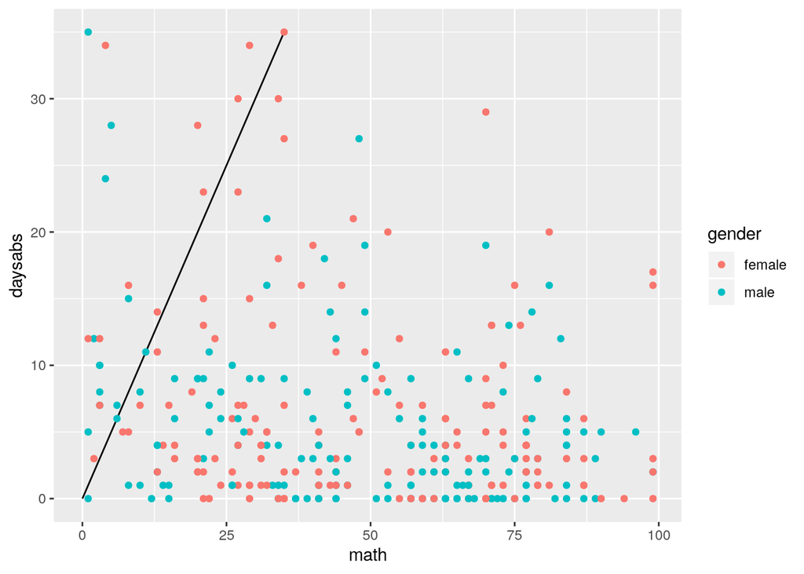

```r
attend_res <- attend %>% mutate(fit_p = predict(fit, type = "response"),
res_p = residuals(fit))

ggplot(attend_res, aes(x = math, y = daysabs, color = gender)) +
geom_line(aes(x = daysabs, y = daysabs), colour = "black") +
geom_point()
```

```r
# ggplot(attend , aes(x= math ,y= daysabs, color = gender))+ geom_point() + geom_smooth()
```

c). Using equations, specify a negative binomial regression model for these data. Identify the random component, the systematic component and the link function.

Answer:-

random component = Y ~ Neg.binom(r, pi)  
systematic component = BetaNot + BetaOneX  
link function:-  
log(mu) = BetaNot + BetaOneX

d). Fit the negative binomial model to these data. Has your interpretation of the coefficients changed compared to the fitted Poisson model? How have the standard errors been impacted?

```r
fit1 <- glm.nb(formula = daysabs ~ ., data = attend)
summary(fit1)
```

```
##
## Call:
## glm.nb(formula = daysabs ~ ., data = attend, init.theta = 0.8705938674,
##     link = log)
##
## Deviance Residuals:
##     Min       1Q   Median       3Q      Max
## -2.0413  -1.0659  -0.3533   0.2983   2.1304
##
## Coefficients:
##              Estimate Std. Error z value Pr(>|z|)
## (Intercept)  2.380579   0.152939  15.566  < 2e-16 ***
## gendermale  -0.269599   0.130290  -2.069   0.0385 *
## math        -0.010561   0.002575  -4.102  4.1e-05 ***
## ---
## Signif. codes:  0 '***' 0.001 '**' 0.01 '*' 0.05 '.' 0.1 ' ' 1
##
## (Dispersion parameter for Negative Binomial(0.8706) family taken to be 1)
##
##     Null deviance: 379.60  on 313  degrees of freedom
## Residual deviance: 357.93  on 311  degrees of freedom
## AIC: 1780.1
##
## Number of Fisher Scoring iterations: 1
##
##
##               Theta:  0.8706
##           Std. Err.:  0.0848
##
##  2 x log-likelihood:  -1772.0740
```

Answer:-

Yes, The interpretation would slightly change for negative binomial from poission model as there will be slight change in coefficient of the parameters.

standard errors have been scaled in negative binomial model and it is biased in poisson distribution.

e).Provide a brief description of how the variance assumptions underlying the models specified in (a) and (c) differ from each other. What is the estimated dispersion parameter for the Negative Binomial model?

Answer:-

The Poisson distribution assumes that the mean and variance are the same. When data shows extra variation that is greater than the mean. This situation is called overdispersion and negative binomial regression is more flexible in that regard than Poisson regression. The negative binomial distribution has one parameter more than the Poisson regression that adjusts the variance independently from the mean.

Estimated dispersion parameter for the negative binomial model is:- 0.8706

f).Using equations, describe how you would calculate AIC for the fitted models. Use AIC to choose between the models fitted above.

```r
#Answer:-

#AIC = -2l + 2p
#where l is log likelihood of the model and p is the number of parameters

#for poisson binomial model :-
 AIC <- -2*as.numeric(logLik(fit))+2*(length(fit$coefficients))
 AIC
```

```
## [1] 2931.868
```

```r
#for negative binomial model :-
 AIC_NB <- -2*as.numeric(logLik(fit1))+2*(length(fit1$coefficients)+1)
 AIC_NB
```

```
## [1] 1780.074
```